# Statistical Analysis & Data Preparation

Character Strength Constellations Across Racial Groups

Kirsten L. Calloway

# 1 Overview

This analysis serves as the statistical foundation for my capstone project, “Where Does Hope Live?” I examine character strength patterns across three racial groups using VIA Institute data (n = 7,047), grounded in Dr. Joseph L. White’s (1984) documentation of psychological strengths in Black communities and Dr. Jacqueline Mattis’s scholarship on generational hope (Hellman & Mattis, 2023). Following QuantCrit principles (Gillborn et al., 2018), I treat observed patterns as reflections of adaptive responses to racialized experiences rather than inherent group characteristics.

# 2 Libraries

```r
library(tidyverse)
library(dplyr)
library(ggplot2)
library(readxl)
library(corrplot)
library(car)
```

# 3 Data Loading and Preparation

## 3.1 Dataset Evolution

This analysis uses data from two sources:

1. **2023 Empirical Study:** My Master’s capstone research examining character strengths, resilience, and multiracial identity. IRB exemption was obtained, and the VIA Institute granted permission for data use.
2. **VIA Institute Retrospective Data:** Additional data provided by the VIA Institute to achieve adequate sample sizes for historically underrepresented populations.

Participants completed an online survey including the VIA Inventory of Strengths (240 items measuring 24 character strengths) and the Brief Resilience Scale (6 items). Character strength scores represent composite means on a 1-5 scale, calculated by the VIA Institute.

The Monoracial sample (Monoracial Black and Monoracial White participants) was collected over a brief period in August 2023 (August 6-9, 2023). The Black-White Biracial sample was collected retrospectively over 48 months (June 2019 through August 2023) to achieve adequate statistical power for this historically underrepresented population. Retrospective data collection for smaller populations is a standard and accepted methodological approach when real-time sampling would yield insufficient sample sizes. The VIA Institute granted permission for use of this data for research purposes.

The original study included only 24 Black-White Biracial participants out of 1,227 total, which was insufficient for robust statistical comparisons. On the advice of my capstone advisor, I stacked the original study data with the retrospective data to ensure credibility and consistency, merging three separate spreadsheets: (1) the original empirical study data, (2) additional Monoracial data, and (3) the retrospective Black-White Biracial data. The combined dataset includes n = 7,047 participants, providing substantially greater statistical power than the original study, particularly for the Black-White Biracial group (n = 3,738 compared to the original n = 24).

```r
# Load dataset
data202_lab3_data <- read_excel("C:/Users/kelal/OneDrive/R Studio/data202/data202_lab3_data.xlsx")
stacked_data <- data202_lab3_data
```

## 3.2 Create Analysis Variables

```r
# Convert Hope from character to numeric
stacked_data$Hope <- as.numeric(stacked_data$Hope)

# Create Race_Group and Geographic_Region
stacked_data <- stacked_data %>%
  mutate(
    Race_Group = case_when(
      Race == "2332" ~ "Monoracial White",
      Race == "2333" ~ "Monoracial Black",
      Race == "2332, 2333" ~ "Black-White Biracial",
      TRUE ~ "Other"
    ),
    Geographic_Region = case_when(
      `JC Y/N` == "Y" ~ "Jim Crow",
      `JC Y/N` == "N" ~ "Non-Jim Crow",
      TRUE ~ NA_character_
    )
  )
```

## 3.3 Define and Convert All 24 Character Strengths

```r
# Define all 24 VIA character strengths
strength_names <- c(
  "Appreciation of Beauty & Excellence", "Bravery", "Love", "Prudence", "Teamwork",
  "Creativity", "Curiosity", "Fairness", "Forgiveness", "Gratitude",
  "Honesty", "Hope", "Humor", "Perseverance", "Judgment",
  "Kindness", "Leadership", "Love of Learning", "Humility", "Perspective",
  "Self-Regulation", "Social Intelligence", "Spirituality", "Zest"
)

# Convert all 24 strengths from character to numeric
for(strength in strength_names) {
  stacked_data[[strength]] <- as.numeric(stacked_data[[strength]])
}
```

## 3.4 Verify Dataset Structure

Confirming the merged dataset dimensions and group distributions:

```r
dim(stacked_data)
```

```
## [1] 7047   82
```

```r
table(stacked_data$Race_Group)
```

```
##
## Black-White Biracial     Monoracial Black     Monoracial White
##                 3738                  441                 2868
```

```r
table(stacked_data$Geographic_Region)
```

```
##
##     Jim Crow Non-Jim Crow
##         2501         4546
```

```r
table(stacked_data$Race_Group, stacked_data$Geographic_Region)
```

```
##
##                        Jim Crow Non-Jim Crow
##   Black-White Biracial     1293         2445
##   Monoracial Black          237          204
##   Monoracial White          971         1897
```

## 3.5 Data Integrity: Missing Values

```r
# Check for missing values across key variables
cat("Missing Hope:", sum(is.na(stacked_data$Hope)), "\n")
```

```
## Missing Hope: 0
```

```r
cat("Missing Race_Group:", sum(is.na(stacked_data$Race_Group)), "\n")
```

```
## Missing Race_Group: 0
```

```r
cat("Missing Geographic_Region:", sum(is.na(stacked_data$Geographic_Region)), "\n")
```

```
## Missing Geographic_Region: 0
```

```r
# Check missing values across all 24 strengths
strength_missing <- sapply(stacked_data[strength_names], function(x) sum(is.na(x)))
cat("\nMissing values across 24 character strengths:\n")
```

```
##
## Missing values across 24 character strengths:
```

```r
print(strength_missing[strength_missing > 0])
```

```
## named integer(0)
```

```r
if(all(strength_missing == 0)) cat("No missing values in any character strength variable.\n")
```

```
## No missing values in any character strength variable.
```

The dataset contains no missing values for any analysis variable. Participants with missing or invalid data were excluded during the Excel data preparation phase.

# 4 Exploratory Data Analysis (EDA)

## 4.1 Descriptive Statistics: Central Tendency and Dispersion

The rubric requires mean, median, SD, and IQR for key variables.

```r
# Hope descriptive statistics: overall
cat("=== HOPE: OVERALL ===\n")
```

```
## === HOPE: OVERALL ===
```

```r
cat("Mean:", round(mean(stacked_data$Hope, na.rm = TRUE), 3), "\n")
```

```
## Mean: 3.798
```

```r
cat("Median:", round(median(stacked_data$Hope, na.rm = TRUE), 3), "\n")
```

```
## Median: 3.75
```

```r
cat("SD:", round(sd(stacked_data$Hope, na.rm = TRUE), 3), "\n")
```

```
## SD: 0.72
```

```r
cat("IQR:", round(IQR(stacked_data$Hope, na.rm = TRUE), 3), "\n")
```

```
## IQR: 0.75
```

```r
cat("Min:", min(stacked_data$Hope, na.rm = TRUE),
    "Max:", max(stacked_data$Hope, na.rm = TRUE), "\n")
```

```
## Min: 1 Max: 5
```

```r
# Hope by Race_Group: mean, median, SD, IQR
stacked_data %>%
  group_by(Race_Group) %>%
  summarize(
    n = n(),
    Mean = round(mean(Hope, na.rm = TRUE), 3),
    Median = round(median(Hope, na.rm = TRUE), 3),
    SD = round(sd(Hope, na.rm = TRUE), 3),
    IQR = round(IQR(Hope, na.rm = TRUE), 3),
    .groups = "drop"
  )
```

```
## # A tibble: 3 × 6
##   Race_Group               n  Mean Median    SD   IQR
##   <chr>                <int> <dbl>  <dbl> <dbl> <dbl>
## 1 Black-White Biracial  3738  3.79   3.75 0.74   1
## 2 Monoracial Black       441  4.10   4.25 0.657  0.75
## 3 Monoracial White      2868  3.76   3.75 0.692  1
```

```r
# Descriptive statistics for all 24 strengths (overall)
strength_descriptives <- stacked_data %>%
  select(all_of(strength_names)) %>%
  pivot_longer(everything(), names_to = "Strength", values_to = "Score") %>%
  group_by(Strength) %>%
  summarize(
    Mean = round(mean(Score, na.rm = TRUE), 3),
    Median = round(median(Score, na.rm = TRUE), 3),
    SD = round(sd(Score, na.rm = TRUE), 3),
    IQR = round(IQR(Score, na.rm = TRUE), 3),
    .groups = "drop"
  ) %>%
  arrange(desc(Mean))

print(strength_descriptives)
```

```
## # A tibble: 24 × 5
##    Strength                             Mean Median    SD   IQR
##    <chr>                               <dbl>  <dbl> <dbl> <dbl>
##  1 Honesty                              4.14   4.25 0.589  0.75
##  2 Kindness                             4.06   4    0.615  0.75
##  3 Fairness                             4.05   4    0.698  0.75
##  4 Humor                                3.95   4    0.794  1
##  5 Judgment                             3.94   4    0.591  0.75
##  6 Perspective                          3.94   4    0.678  1
##  7 Social Intelligence                  3.92   4    0.638  1
##  8 Appreciation of Beauty & Excellence  3.89   4    0.754  1
##  9 Curiosity                            3.89   4    0.675  1
## 10 Love of Learning                     3.86   4    0.693  1
## # ℹ 14 more rows
```

## 4.2 Visual Distributions

### 4.2.1 Histogram: Hope Score Distribution

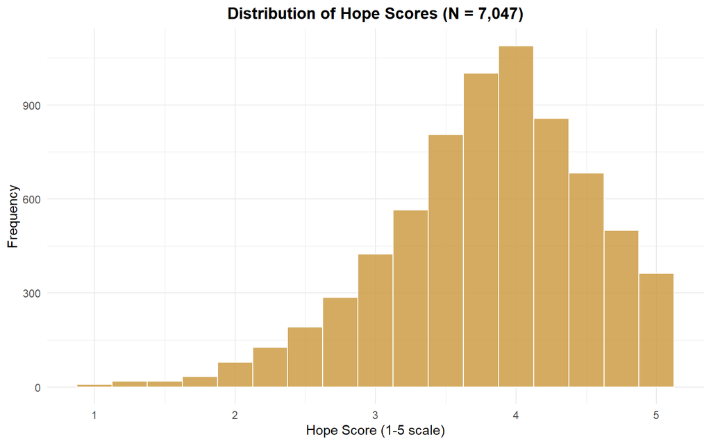

```r
ggplot(stacked_data, aes(x = Hope)) +
  geom_histogram(binwidth = 0.25, fill = "#C9963A", color = "white", alpha = 0.8) +
  labs(title = "Distribution of Hope Scores (N = 7,047)",
       x = "Hope Score (1-5 scale)", y = "Frequency") +
  theme_minimal() +
  theme(plot.title = element_text(hjust = 0.5, face = "bold"))
```

### 4.2.2 Boxplot: Hope by Racial Group

This visualization reveals that Monoracial Black participants demonstrate higher Hope scores with a higher median and tighter distribution compared to the other two groups.

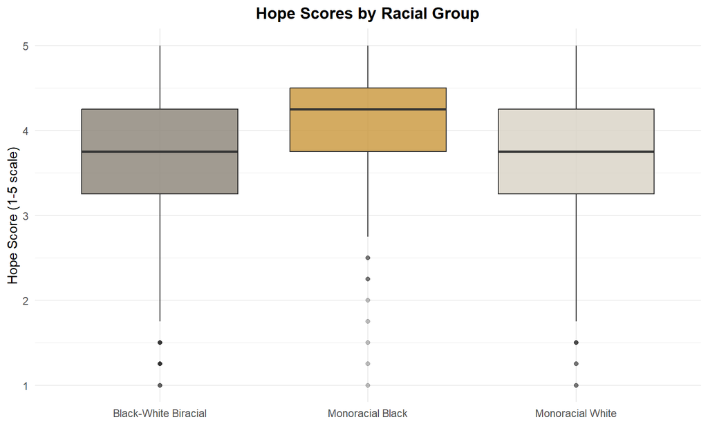

```r
race_colors <- c("Monoracial Black" = "#C9963A",
                 "Black-White Biracial" = "#8A8276",
                 "Monoracial White" = "#D8D2C4")

ggplot(stacked_data, aes(x = Race_Group, y = Hope, fill = Race_Group)) +
  geom_boxplot(alpha = 0.8, outlier.alpha = 0.3) +
  scale_fill_manual(values = race_colors) +
  labs(title = "Hope Scores by Racial Group",
       x = "", y = "Hope Score (1-5 scale)") +
  theme_minimal() +
  theme(plot.title = element_text(hjust = 0.5, face = "bold"),
        legend.position = "none")
```

### 4.2.3 Density Plot: Hope Distribution by Racial Group

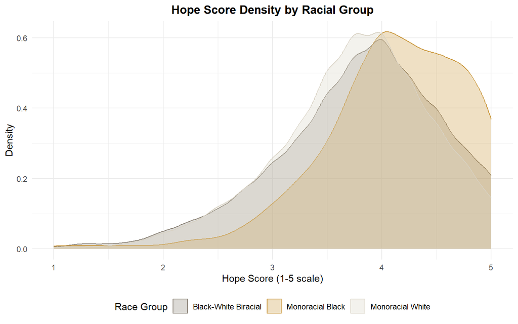

```r
ggplot(stacked_data, aes(x = Hope, fill = Race_Group, color = Race_Group)) +
  geom_density(alpha = 0.3) +
  scale_fill_manual(values = race_colors) +
  scale_color_manual(values = race_colors) +
  labs(title = "Hope Score Density by Racial Group",
       x = "Hope Score (1-5 scale)", y = "Density",
       fill = "Race Group", color = "Race Group") +
  theme_minimal() +
  theme(plot.title = element_text(hjust = 0.5, face = "bold"),
        legend.position = "bottom")
```

## 4.3 Correlation Analysis

### 4.3.1 Correlation: Hope, Zest, and Bravery with Resilience

Based on Martinez-Marti and Ruch (2017), I examine whether Hope, Zest, and Bravery are associated with resilience (R1) in this racially diverse sample.

```r
# Ensure R1 is numeric
stacked_data$R1 <- as.numeric(stacked_data$R1)

# Correlations with resilience
cor_hope <- cor.test(stacked_data$Hope, stacked_data$R1, use = "complete.obs")
cor_zest <- cor.test(stacked_data$Zest, stacked_data$R1, use = "complete.obs")
cor_bravery <- cor.test(stacked_data$Bravery, stacked_data$R1, use = "complete.obs")

cat("Hope-Resilience: r =", round(cor_hope$estimate, 3),
    "p =", format.pval(cor_hope$p.value, digits = 3), "\n")
```

```
## Hope-Resilience: r = 0.473 p = <2e-16
```

```r
cat("Zest-Resilience: r =", round(cor_zest$estimate, 3),
    "p =", format.pval(cor_zest$p.value, digits = 3), "\n")
```

```
## Zest-Resilience: r = 0.36 p = <2e-16
```

```r
cat("Bravery-Resilience: r =", round(cor_bravery$estimate, 3),
    "p =", format.pval(cor_bravery$p.value, digits = 3), "\n")
```

```
## Bravery-Resilience: r = 0.24 p = <2e-16
```

### 4.3.2 Correlation Matrix: 24 Character Strengths

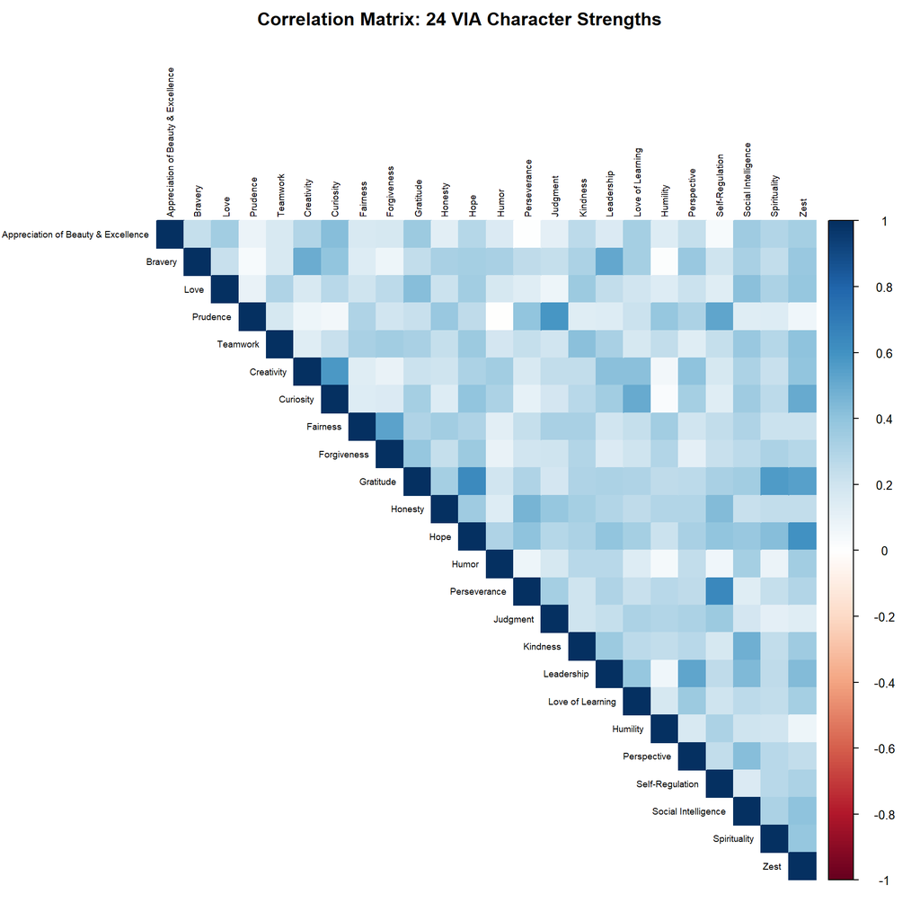

```r
# Compute correlation matrix for all 24 strengths
strength_cor <- cor(stacked_data[strength_names], use = "complete.obs")

# Visualize
corrplot(strength_cor, method = "color", type = "upper",
         tl.cex = 0.6, tl.col = "black",
         title = "Correlation Matrix: 24 VIA Character Strengths",
         mar = c(0, 0, 2, 0))
```

This matrix reveals the inter-relationships among the 24 character strengths and is relevant for the multicollinearity diagnosis below.

# 5 Hypothesis Testing

## 5.1 Formal Hypotheses

**Research Question:** Does Hope differ by racial identity and geographic context?

**Hypothesis 1 (Race):**

- H0: There is no significant difference in mean Hope scores across Monoracial Black, Monoracial White, and Black-White Biracial groups.
- H1: At least one racial group differs significantly in mean Hope scores.

**Hypothesis 2 (Geography):**

- H0: There is no significant difference in mean Hope scores between Jim Crow and Non-Jim Crow states.
- H1: Mean Hope scores differ significantly between Jim Crow and Non-Jim Crow states.

**Hypothesis 3 (Interaction):**

- H0: The effect of geographic region on Hope does not differ by racial group.
- H1: The effect of geographic region on Hope depends on racial group.

## 5.2 Two-Way ANOVA

I selected a two-way ANOVA because the research question involves one continuous dependent variable (Hope) and two categorical independent variables (Race_Group, Geographic_Region), and I am testing both main effects and their interaction.

```r
model <- aov(Hope ~ Race_Group * Geographic_Region, data = stacked_data)
summary(model)
```

```
##                                Df Sum Sq Mean Sq F value Pr(>F)
## Race_Group                      2     47  23.273  45.425 <2e-16 ***
## Geographic_Region               1      3   2.829   5.521 0.0188 *
## Race_Group:Geographic_Region    2      0   0.227   0.443 0.6419
## Residuals                    7041   3607   0.512
## ---
## Signif. codes:  0 '***' 0.001 '**' 0.01 '*' 0.05 '.' 0.1 ' ' 1
```

## 5.3 Interpretation

The two-way ANOVA reveals:

- **Race_Group:** F = 45.43, p < .001. I reject H0. Hope scores differ significantly across racial groups. Monoracial Black participants demonstrate the highest mean Hope (M = 4.10), followed by Black-White Biracial (M = 3.79) and Monoracial White (M = 3.76).
- **Geographic_Region:** F = 5.52, p = .019. I reject H0. A small but statistically significant difference exists, with Jim Crow states showing slightly higher Hope (M = 3.84 vs. 3.78).
- **Interaction:** F = 0.44, p = .642. I fail to reject H0. The geographic pattern does not differ by racial group. All three groups show the same slight elevation in Jim Crow states.

The p-value for Race_Group (p < .001) indicates that the probability of observing differences this large by chance alone is less than 0.1%. In context, this means that racial identity is associated with meaningfully different levels of Hope, with Monoracial Black participants scoring highest regardless of geographic location.

```r
# 6-cell descriptive comparison
stacked_data %>%
  group_by(Race_Group, Geographic_Region) %>%
  summarize(
    n = n(),
    Mean_Hope = round(mean(Hope, na.rm = TRUE), 3),
    SD_Hope = round(sd(Hope, na.rm = TRUE), 3),
    .groups = "drop"
  )
```

```
## # A tibble: 6 × 5
##   Race_Group           Geographic_Region     n Mean_Hope SD_Hope
##   <chr>                <chr>             <int>     <dbl>   <dbl>
## 1 Black-White Biracial Jim Crow           1293      3.83   0.724
## 2 Black-White Biracial Non-Jim Crow       2445      3.77   0.748
## 3 Monoracial Black     Jim Crow            237      4.12   0.657
## 4 Monoracial Black     Non-Jim Crow        204      4.08   0.659
## 5 Monoracial White     Jim Crow            971      3.77   0.679
## 6 Monoracial White     Non-Jim Crow       1897      3.75   0.699
```

## 5.4 Visualization: Hope by Race and Geography

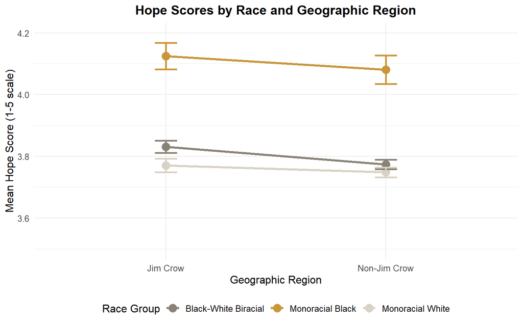

```r
plot_data <- stacked_data %>%
  group_by(Race_Group, Geographic_Region) %>%
  summarize(
    Mean_Hope = mean(Hope, na.rm = TRUE),
    SE = sd(Hope, na.rm = TRUE) / sqrt(n()),
    .groups = "drop"
  )

ggplot(plot_data, aes(x = Geographic_Region, y = Mean_Hope,
                      color = Race_Group, group = Race_Group)) +
  geom_point(size = 4) +
  geom_line(linewidth = 1.2) +
  geom_errorbar(aes(ymin = Mean_Hope - SE, ymax = Mean_Hope + SE),
                width = 0.1, linewidth = 1) +
  scale_color_manual(values = c("Monoracial Black" = "#C9963A",
                                "Black-White Biracial" = "#8A8276",
                                "Monoracial White" = "#D8D2C4")) +
  labs(title = "Hope Scores by Race and Geographic Region",
       x = "Geographic Region", y = "Mean Hope Score (1-5 scale)",
       color = "Race Group") +
  ylim(3.5, 4.2) +
  theme_minimal() +
  theme(text = element_text(size = 12),
        plot.title = element_text(hjust = 0.5, face = "bold"),
        legend.position = "bottom")
```

# 6 Character Strength Constellation Analysis

## 6.1 Rankings by Racial Group

```r
# Calculate means and rank within each group
strength_by_race <- stacked_data %>%
  select(Race_Group, all_of(strength_names)) %>%
  pivot_longer(cols = all_of(strength_names),
               names_to = "Strength", values_to = "Score") %>%
  group_by(Race_Group, Strength) %>%
  summarize(n = sum(!is.na(Score)),
            Mean = mean(Score, na.rm = TRUE),
            SD = sd(Score, na.rm = TRUE),
            .groups = "drop")

strength_rankings <- strength_by_race %>%
  group_by(Race_Group) %>%
  mutate(Rank = rank(-Mean, ties.method = "min")) %>%
  arrange(Race_Group, Rank)
```

```r
# Top 10 for each group
cat("=== MONORACIAL BLACK TOP 10 ===\n")
```

```
## === MONORACIAL BLACK TOP 10 ===
```

```r
strength_rankings %>%
  filter(Race_Group == "Monoracial Black", Rank <= 10) %>%
  select(Rank, Strength, Mean) %>%
  print()
```

```
## # A tibble: 10 × 4
## # Groups:   Race_Group [1]
##    Race_Group        Rank Strength             Mean
##    <chr>            <int> <chr>               <dbl>
##  1 Monoracial Black     1 Fairness             4.25
##  2 Monoracial Black     2 Honesty              4.23
##  3 Monoracial Black     3 Perspective          4.14
##  4 Monoracial Black     4 Gratitude            4.12
##  5 Monoracial Black     5 Spirituality         4.11
##  6 Monoracial Black     6 Hope                 4.10
##  7 Monoracial Black     7 Kindness             4.09
##  8 Monoracial Black     8 Judgment             4.08
##  9 Monoracial Black     9 Love of Learning     4.07
## 10 Monoracial Black    10 Social Intelligence  4.00
```

```r
cat("\n=== BLACK-WHITE BIRACIAL TOP 10 ===\n")
```

```
##
## === BLACK-WHITE BIRACIAL TOP 10 ===
```

```r
strength_rankings %>%
  filter(Race_Group == "Black-White Biracial", Rank <= 10) %>%
  select(Rank, Strength, Mean) %>%
  print()
```

```
## # A tibble: 10 × 4
## # Groups:   Race_Group [1]
##    Race_Group            Rank Strength                            Mean
##    <chr>                <int> <chr>                              <dbl>
##  1 Black-White Biracial     1 Honesty                             4.11
##  2 Black-White Biracial     2 Kindness                            4.07
##  3 Black-White Biracial     3 Fairness                            4.03
##  4 Black-White Biracial     4 Humor                               3.99
##  5 Black-White Biracial     5 Perspective                         3.98
##  6 Black-White Biracial     6 Social Intelligence                 3.97
##  7 Black-White Biracial     7 Judgment                            3.95
##  8 Black-White Biracial     8 Curiosity                           3.93
##  9 Black-White Biracial     9 Appreciation of Beauty & Excellen…  3.91
## 10 Black-White Biracial    10 Love of Learning                    3.83
```

```r
cat("\n=== MONORACIAL WHITE TOP 10 ===\n")
```

```
##
## === MONORACIAL WHITE TOP 10 ===
```

```r
strength_rankings %>%
  filter(Race_Group == "Monoracial White", Rank <= 10) %>%
  select(Rank, Strength, Mean) %>%
  print()
```

```
## # A tibble: 10 × 4
## # Groups:   Race_Group [1]
##    Race_Group        Rank Strength                             Mean
##    <chr>            <int> <chr>                               <dbl>
##  1 Monoracial White     1 Honesty                              4.18
##  2 Monoracial White     2 Fairness                             4.05
##  3 Monoracial White     3 Kindness                             4.03
##  4 Monoracial White     4 Judgment                             3.90
##  5 Monoracial White     5 Humor                                3.88
##  6 Monoracial White     6 Appreciation of Beauty & Excellence  3.88
##  7 Monoracial White     7 Love of Learning                     3.87
##  8 Monoracial White     8 Perspective                          3.85
##  9 Monoracial White     9 Social Intelligence                  3.84
## 10 Monoracial White    10 Curiosity                            3.82
```

Three strengths appear in the Monoracial Black top 10 that are entirely absent from both other groups: Gratitude (rank 4), Spirituality (rank 5), and Hope (rank 6). This pattern is consistent with Dr. White’s (1984) identification of spirituality as a key psychological strength in Black communities.

# 7 Pre-ML Data Diagnosis and Remediation

This section prepares the dataset for future machine learning classification by diagnosing and addressing data quality issues that would compromise model performance.

## 7.1 Multicollinearity Check

Because the 24 character strengths are psychological constructs measured by the same instrument, some degree of correlation is expected. High multicollinearity among features would inflate variance in model coefficients and reduce interpretability.

```r
# Check for highly correlated strength pairs (r > 0.70)
high_cor <- which(abs(strength_cor) > 0.70 & strength_cor < 1, arr.ind = TRUE)
if(nrow(high_cor) > 0) {
  cat("Strength pairs with r > 0.70:\n")
  for(i in 1:nrow(high_cor)) {
    row_name <- rownames(strength_cor)[high_cor[i, 1]]
    col_name <- colnames(strength_cor)[high_cor[i, 2]]
    r_val <- round(strength_cor[high_cor[i, 1], high_cor[i, 2]], 3)
    if(high_cor[i, 1] < high_cor[i, 2]) {
      cat(" ", row_name, "&", col_name, ": r =", r_val, "\n")
    }
  }
} else {
  cat("No strength pairs exceed r = 0.70. Multicollinearity is not severe.\n")
}
```

```
## No strength pairs exceed r = 0.70. Multicollinearity is not severe.
```

```r
# VIF using Hope as dependent variable with all other strengths as predictors
# This tests whether any predictor is redundant given the others
vif_model <- lm(Hope ~ `Appreciation of Beauty & Excellence` + Bravery + Love +
                  Prudence + Teamwork + Creativity + Curiosity + Fairness +
                  Forgiveness + Gratitude + Honesty + Humor + Perseverance +
                  Judgment + Kindness + Leadership + `Love of Learning` +
                  Humility + Perspective + `Self-Regulation` +
                  `Social Intelligence` + Spirituality + Zest,
                data = stacked_data)

vif_values <- vif(vif_model)
cat("\n=== Variance Inflation Factors ===\n")
```

```
##
## === Variance Inflation Factors ===
```

```r
print(round(vif_values, 2))
```

```
## `Appreciation of Beauty & Excellence`
##                                  1.51
##                               Bravery
##                                  1.78
##                                  Love
##                                  1.47
##                              Prudence
##                                  2.15
##                              Teamwork
##                                  1.54
##                            Creativity
##                                  1.88
##                             Curiosity
##                                  2.09
##                              Fairness
##                                  1.66
##                           Forgiveness
##                                  1.63
##                             Gratitude
##                                  2.13
##                               Honesty
##                                  1.63
##                                 Humor
##                                  1.35
##                          Perseverance
##                                  1.97
##                              Judgment
##                                  1.82
##                              Kindness
##                                  1.63
##                            Leadership
##                                  2.03
##                    `Love of Learning`
##                                  1.63
##                              Humility
##                                  1.42
##                           Perspective
##                                  1.79
##                     `Self-Regulation`
##                                  2.19
##                 `Social Intelligence`
##                                  1.87
##                          Spirituality
##                                  1.63
##                                  Zest
##                                  2.22
```

```r
cat("\nVIF > 5 (potential concern):", sum(vif_values > 5), "variables\n")
```

```
##
## VIF > 5 (potential concern): 0 variables
```

```r
cat("VIF > 10 (serious multicollinearity):", sum(vif_values > 10), "variables\n")
```

```
## VIF > 10 (serious multicollinearity): 0 variables
```

**Remediation strategy:** If any VIF exceeds 10, I would consider dropping the redundant feature or using PCA to reduce dimensionality. If VIF values are moderate (5-10), I would note this as a consideration for model selection, favoring regularized methods (ridge or lasso regression) that handle correlated predictors more robustly than standard logistic regression.